# Coursework Report

*N* removed NAs: 3

*N* removed typo: 1

*N* removed <18: 26

*N* total clean: 120

| Group | *N* | *M*<sub>age</sub> | *M*<sub>rating</sub> |
| --- | --- | --- | --- |
| Control | 61 | 20.95 | 6.23 |
| Experim | 59 | 21.42 | 7.05 |

**Main analysis results**

*t*(118) = -6.06, *p* < .001

[interactive chart not shown]

[figure not shown]

[interactive chart not shown]

# Coursework Report

Analysing Data, Spring 2020

# Methods

## Participants

Table 1 *Summary of Participants by Experimental Condition*

| Condition | N | *M*<sub>age</sub> | *SD*<sub>age</sub> |
| --- | --- | --- | --- |
| control | 61 | 20.95 | 2.21 |
| experimental | 59 | 21.42 | 2.30 |

## Design

The study investigated the conceptual hypothesis ‘Does colour influence attractiveness?’. Participants saw one of two pictures of a moderately attractive man in a frame - a white frame (the control condition) or a red frame (the experimental condition ) and then had to give their responses on an attractiveness rating scale. Attractivenss was measured using ratings of 1 (not at all attractive) to 9 (extremely attractive) on three questions: ‘How pleasant is this person to look at?’, ‘How attractive do you think this person is?’, and ‘If I were to meet the person face to face, i would think he is attractive’. Colour is a factor created using the two levels of the independent variable: red and white frames, while attractiveness is a rating created using a range of scores from 1-9 where a higher score indicated more attractiveness. Therefore, if a condition has more high ratings of attractivenss, this should be due to the manipulation of the frame colour. The operational hypothesis of the study is ‘Does viewing a different colour frame around the image of a moderately attractive male influence the mean ratings of his attractiveness?’. This will be tested using the t-test statistic.

# Results

The general pattern of data indicated that participants rated the male as more attractive in the red condition (*M* = 7.05) than those in the white condition (*M* = 6.23). This means that participants, on average, rated the male as more attractive when the picture had a red frame in comparison to a white frame.

A Composite score was calculated by taking the mean of each participant’s scores on the three items (‘How pleasant is this person to look at?’, ‘How attractive do you think this person is?’, and ‘If I were to meet the person face to face, i would think he is attractive’) participants had to answer on a scale of 1-9. Composite score allows us to capture all three ratings together which can be seen in the graph below.

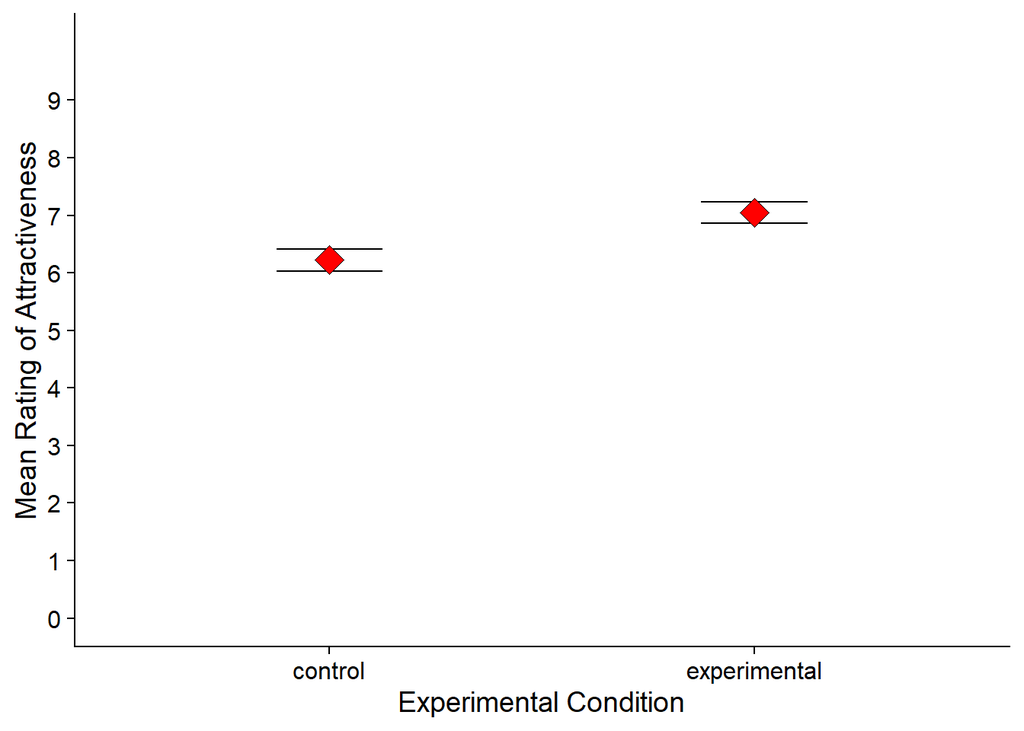

Figure 1. Means plot of Composite Score by Experimental Condition.

# Discussion

The main finding of the study supports the suggestion that colour influences participants’ mean attractiveness ratings. Specifically, the results show that the colour red enhances perceived attractiveness of the male. Thus, according to this study, the research question ‘Does colour influence attractiveness?’ is confirmed. This compliments the original study which found that “colour influences participants’ ratings without their awareness” (Elliot, et al., 2010). However, the study cannot tell us much about the influence initial attraction (or lack thereof) on the rating scale, as well as beyond the three items used to measure attractiveness.

While the findings of this replication do not differ from the original, other studies in the research field undermine its conclusion. Peperkoorn, Roberts, & Pollet, 2016, aimed to replicate the ‘red effect’ while distinguishing between short- and long-term mating motivations with a sample of 206 male participants. The study assessed attractiveness ratings of a woman dressed in white, black, or red clothing and asked questions based on Schwarz & Singer, 2013, in both short- and long-term mating contexts. Participants were assigned to either a short-term scenario, where they answered questions about sexual attraction, or a long-term scenario where they answered questions about a woman’s perceived faithfulness. Unlike the findings of the replication research, here that the woman in white was rated most attractive in comparison to the red and black condition. When limiting the sample to other age groups, the colour red did not increase the attractiveness rating of the woman. Finally, there was no significant difference between the attractiveness rating of the woman regardless of the mating context. The findings of this study demonstrate a different pattern of results and thus a different answer to the research question – that the colour red is not significant for increasing perceived attractiveness as suggested by the original research (Elliot, et al., 2010) and the replication study. This calls into question the relevancy of the research field – ‘Does colour influence perceived attractiveness?’, perhaps suggesting that colour has no real bearing on perceived attractiveness.

Nevertheless, this difference in results could perhaps be attributed to the study design: Peperkoorn et al, 2016 used a sample of men rather than women. Hesslinger, Goldbach, & Carbon, 2015 replicated the basic elements of the Elliot et al study using student volunteers. Participants (17 male and 72 female) were presented with a photo of a young man on either a red or white background, dependent on the condition they were assigned to. They were then asked to rate their perceived attractiveness of the man. Overall, the findings did not indicate any significant impact of red in their study suggesting that colour does not impact the rating of attractiveness. Furthermore, when accounting for a gender difference, splitting the data by gender, there remained no significant effect of colour condition on attractiveness rating. However, in their second experiment, the researchers increased the variance of the stimuli by presenting multiple men wearing different attire (formal and casual). With this manipulation, they found a significant effect of attire style, as males dressed in formal attire were rated as more attractive compared to those in casual apparel. This poses a different branch within the research field, focusing instead on the effect of apparel style on perceived attractiveness as this may be more important that merely looking at the effect of colour. In future replications of the original research (Elliot, et al., 2010) participants could instead be asked to rate the attractiveness of males in these different types of apparel while also manipulating the background colour. Research could then investigate whether the colour red plays a role in higher ratings of attractiveness in conditions where the apparel of the male is the same but the colour frame is different (e.g. red or white).

A strength of the research is that is easy to replicate, allowing for other researchers to confirm or disconfirm the findings. For example, the study used a standardised procedure where participants were shown a picture of a moderately attractive male in a red or white frame, and then asked to rate his attractiveness from 1-9 on three items. Research investigating the influence of colour on attractiveness has often replicated the basic elements of the procedure of presenting a photo and then asking participants questions for example, Peperkoorn, Roberts, & Pollet, 2016 & Hesslinger, Goldbach, & Carbon, 2015. While the findings may not have been replicated in these particular studies, the controlled element of the experiment makes replicating the procedure rather practical. Therefore, the study can be thoroughly repeated to test for the influence of colour on attractiveness.

A limitation of the research by Elliot et al, 2010, is that the viewing time participants were given did not exceed 5 seconds. Research has suggested that the amount of time participants are allowed to look at the photo may influence the perceived attractiveness of the male. For instance, Peperkoorn, Roberts, & Pollet, 2016, allowed participants to look at the picture for as long as they felt necessary. This is important because, in this study, the colour red did not influence the attractiveness ratings. On the other hand, Steven G Young, 2015, found that “initial female attractiveness moderates the influence of red on judgments of attractiveness even when the faces are viewed for extremely short exposures” (Young, 2015). Therefore, to improve the original study, participants should be allowed to look at the photo for as long as they please in some conditions, and for a specific amount of time (no longer than 5 seconds) in another condition, where a comparison on how this moderated the red effect could then be drawn. Moreover, with this probability of time effecting attractiveness ratings, future research could further investigate how the red effect may be influenced by viewing time.

Another limitation of the original study is that it specifically used a young Caucasian male to present to the participants. This raises issues of individual differences purely on attraction to the male, as preferences likely play a role. For example, Young, 2015, conducted a study where participants were presented with 40 images to investigate the baseline attractiveness on the red effect. Young assessed rating scores of men’s attraction to female faces when they were pre-rated as attractive or unattractive. Results indicated that red influenced the attractiveness of females (increasing their perceived attractiveness) when they were pre-rated as attractive but had no effect when they were pre-rated as unattractive (Young, 2015). This is important because baseline attractiveness may have acted as a confounding variable in the Elliot, et al., 2010, research. Ergo, to improve the original study, future research could take this approach of determining a baseline of attractiveness through the use of 40 images and then investigating the red effect.

In conclusion, the replication study results suggested that a red frame increases the ratings of attractiveness of the pictured male. However, the implications of research in this field suggest that the red effect is not entirely significant and thus we cannot conclude that it has any real influence on attractiveness ratings. Nevertheless, as the research field into the influence of colour further expands, focus should be placed on controlling the influence of apparel, viewing time, and determining a baseline of attractiveness as research looking at all three indicates that they mediate the red effect.

# References

Elliot, A. J., Kayser, D. N., Greitemeyer, T., Lichtenfeld, S., Gramzow, R. H., Maier, M. A., & Liu, H. (2010). Red, rank, and romance in women viewing men. Journal of Experimental Psychology: General, 403.

Hesslinger, V. M., Goldbach, L., & Carbon, C. (2015). Men in red: A reexamination of the red-attractiveness effect. Psychonomic Bulletin & Review, 1142-1148.

Peperkoorn, L., Roberts, S., & Pollet, T. (2016). Revisiting the Red Effect on Attractiveness and Sexual Receptivity: No Effect of the Color Red on Human Mate Preferences. Evolutionary Psychology.

Schwarz, S., & Singer, M. (2013). Romantic red revisited: Red enhances men’s attraction to young, but not menopausal women. Journal of Experimental Social Psychology.

Young, S. G. (2015). The effect of red on male perceptions of female attractiveness: Moderation by baseline attractiveness of female faces. European Journal of Social Psychology, 146-151.